# Coronavirus US - USA Facts

davegoblue

6/6/2021

## Background

This module builds on code contained in Coronavirus_Statistics_USAF_v005.Rmd. This file includes the latest code for analyzing data from [USA Facts](https://usafacts.org/visualizations/coronavirus-covid-19-spread-map/). USA Facts maintains data on cases and deaths by county for coronavirus in the US. Downloaded data are unique by county with date as a column and a separate file for each of cases, deaths, and population.

The intent of this code is to source updated functions that allow for readRunUSAFacts() to be run to obtain, read, process, and analyze data from USA Facts.

## Sourcing Functions

The tidyverse library is loaded, and the functions used for CDC daily processing are sourced. Additionally, specific functions for USA Facts are also sourced:

```r
library(tidyverse)
# Functions are available in source file
source("./Generic_Added_Utility_Functions_202105_v001.R")
source("./Coronavirus_CDC_Daily_Functions_v001.R")
source("./Coronavirus_USAF_Functions_v001.R")
```

Further, the mapping file specific to USA Facts is sourced:

```r
source("./Coronavirus_USAF_Default_Mappings_v001.R")
```

Updated functions for diagnoseClusters(), createDetailedSummaries(), createSummary(), and helperSummaryMap() are added to Coronavirus_USAF_Functions_v001.R. These functions should be checked for consistency with state-level data with just a single copy kept later.

## Example Process

The functions are tested on previously downloaded data, with results cached:

```
##
## No file has been downloaded, will use existing file: ./RInputFiles/Coronavirus/covid_confirmed_usafacts_downloaded_20220308.csv
```

```
##
## *** File has been checked for uniqueness by: countyFIPS countyName state stateFIPS
##
##
## *** File has been checked for uniqueness by: countyFIPS stateFIPS date
```

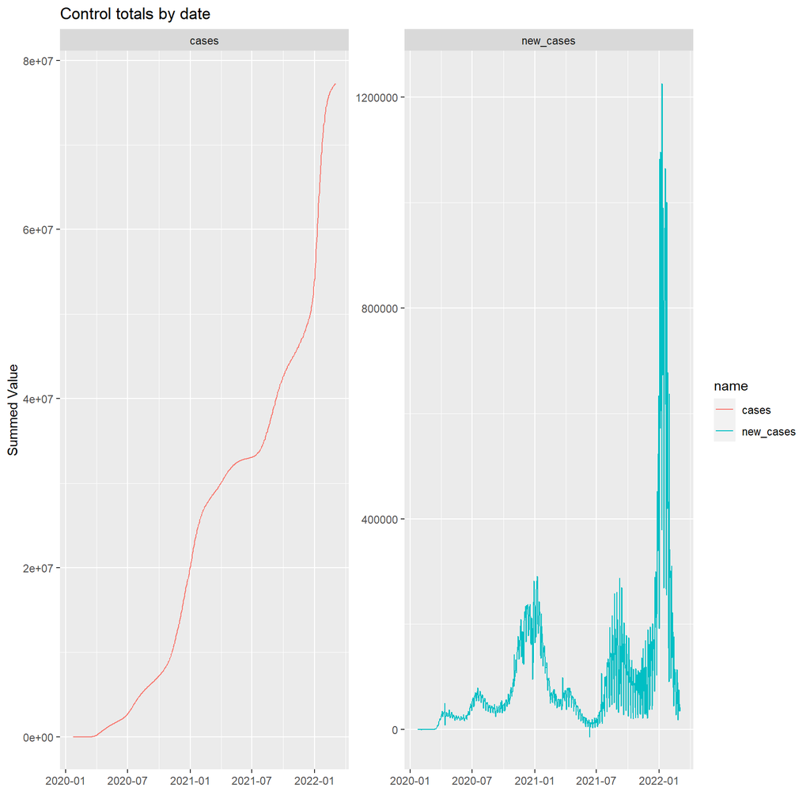

```
##
##
## Checking for similarity of: column names
## In reference but not in current:
## In current but not in reference:
##
## Checking for similarity of: date
## In reference but not in current: 0
## In current but not in reference: 32
## Detailed differences available in: ./RInputFiles/Coronavirus/USAF_NewData_20220308_chk_v005.log
##
## Checking for similarity of: county
## In reference but not in current:
## In current but not in reference:
```

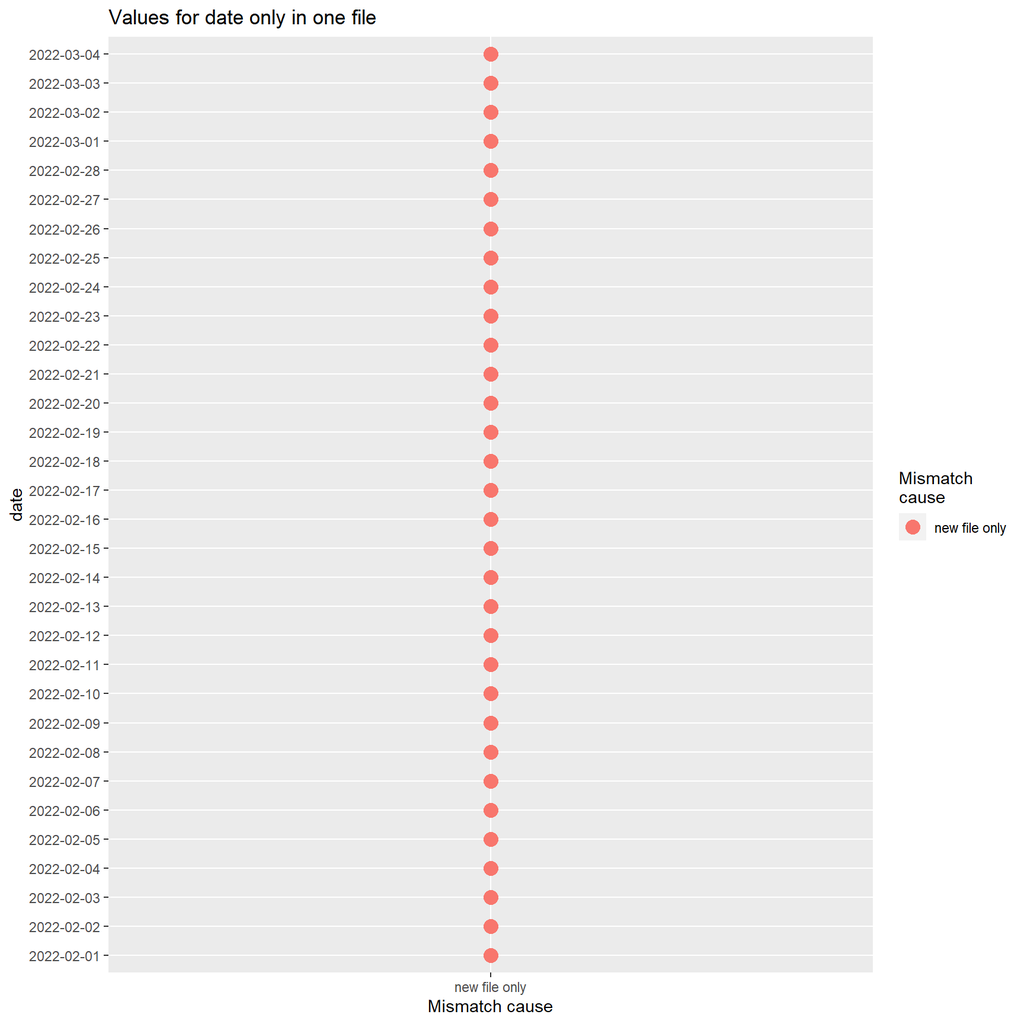

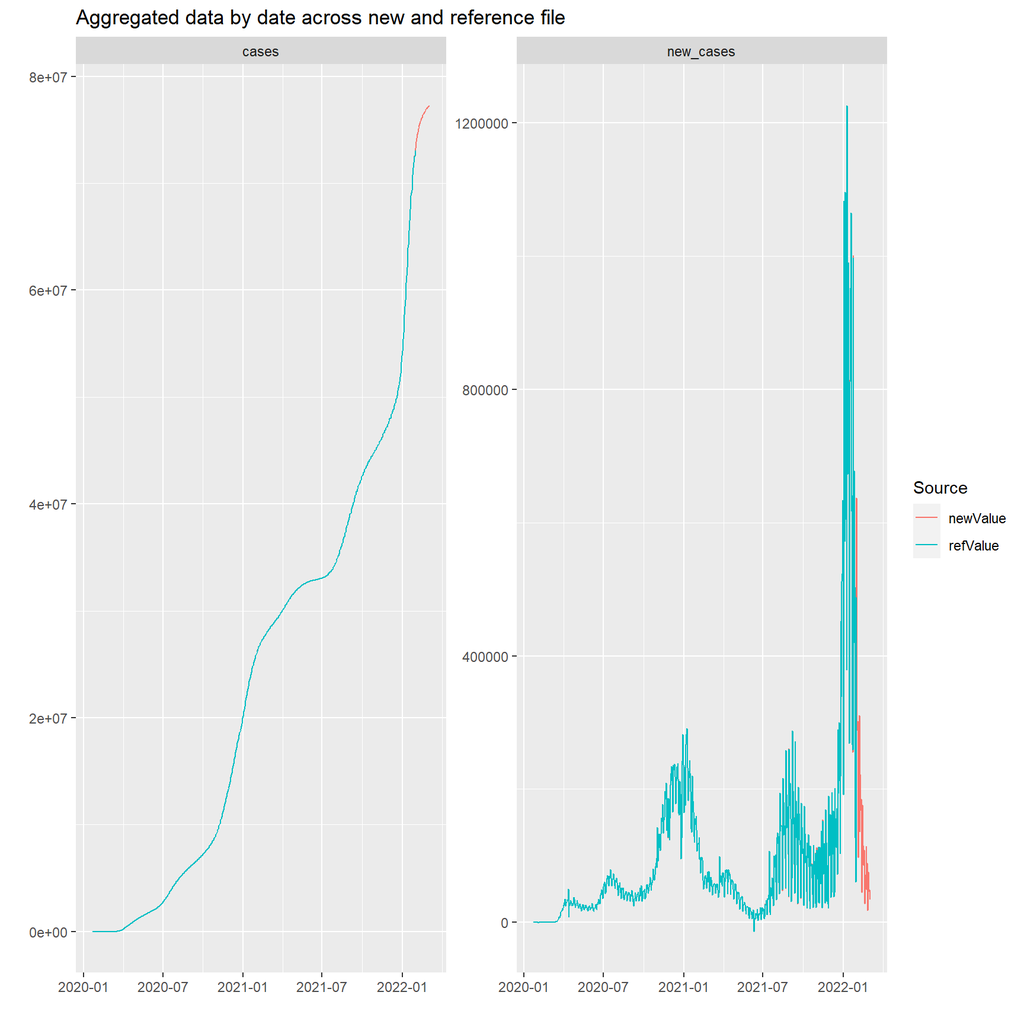

```
##
##
## ***Differences of at least 5 and at least 5%
##
## 6 records
## Detailed output available in log: ./RInputFiles/Coronavirus/USAF_NewData_20220308_chk_v005.log
```

```
##
##
## ***Differences of at least 0 and at least 0.1%
##
## 228 records
## Detailed output available in log: ./RInputFiles/Coronavirus/USAF_NewData_20220308_chk_v005.log
##
##
## No file has been downloaded, will use existing file: ./RInputFiles/Coronavirus/covid_deaths_usafacts_downloaded_20220308.csv
```

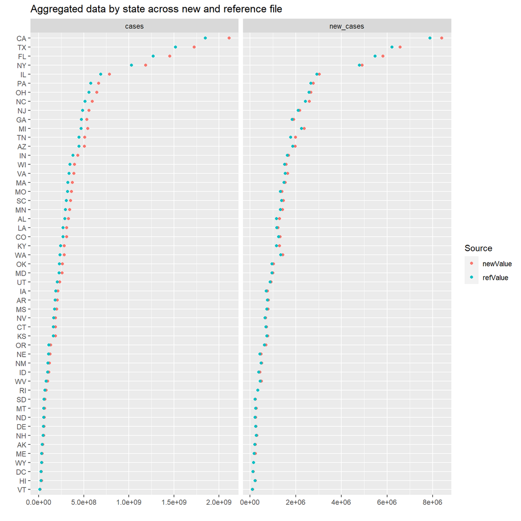

```
##
## *** File has been checked for uniqueness by: countyFIPS countyName state stateFIPS
##
##
## *** File has been checked for uniqueness by: countyFIPS stateFIPS date
```

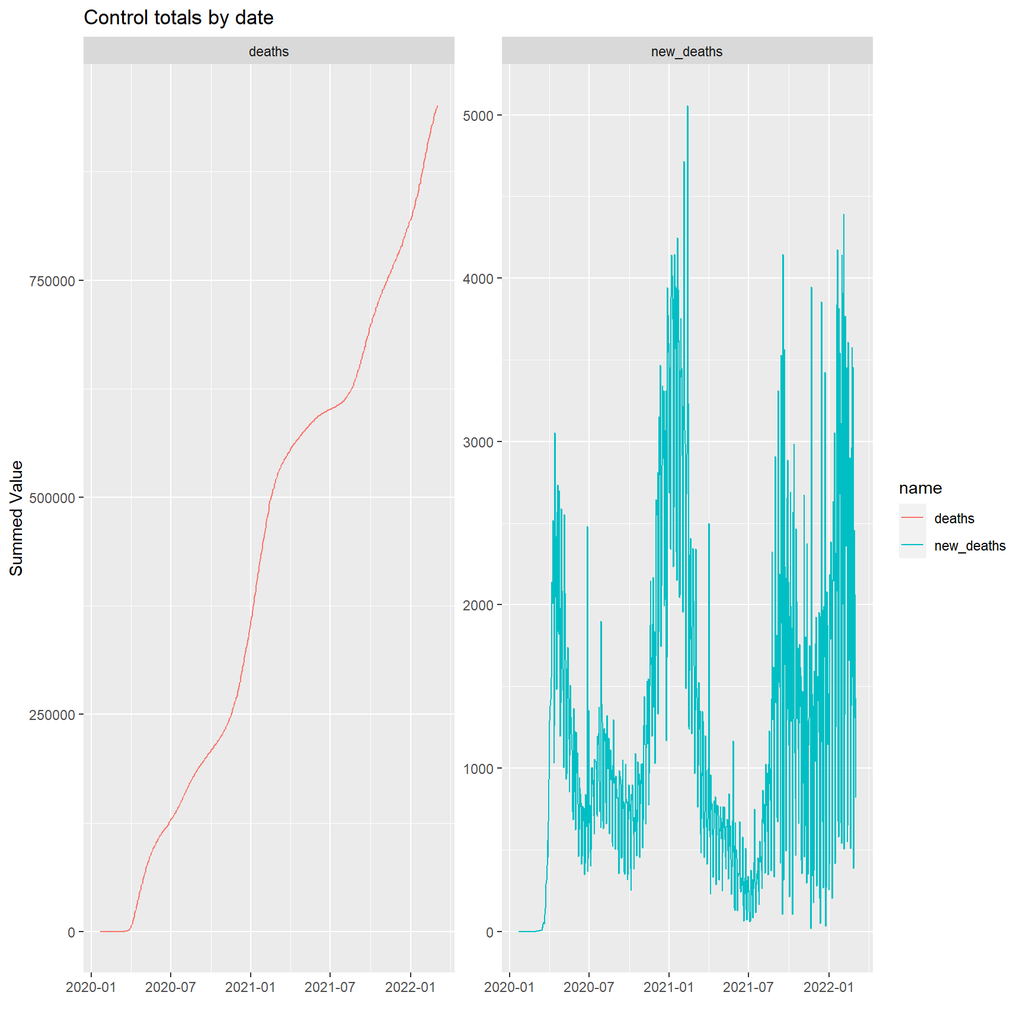

```
##
##
## Checking for similarity of: column names
## In reference but not in current:
## In current but not in reference:
##
## Checking for similarity of: date
## In reference but not in current: 0
## In current but not in reference: 32
## Detailed differences available in: ./RInputFiles/Coronavirus/USAF_NewData_20220308_chk_v005.log
##
## Checking for similarity of: county
## In reference but not in current:
## In current but not in reference:
```

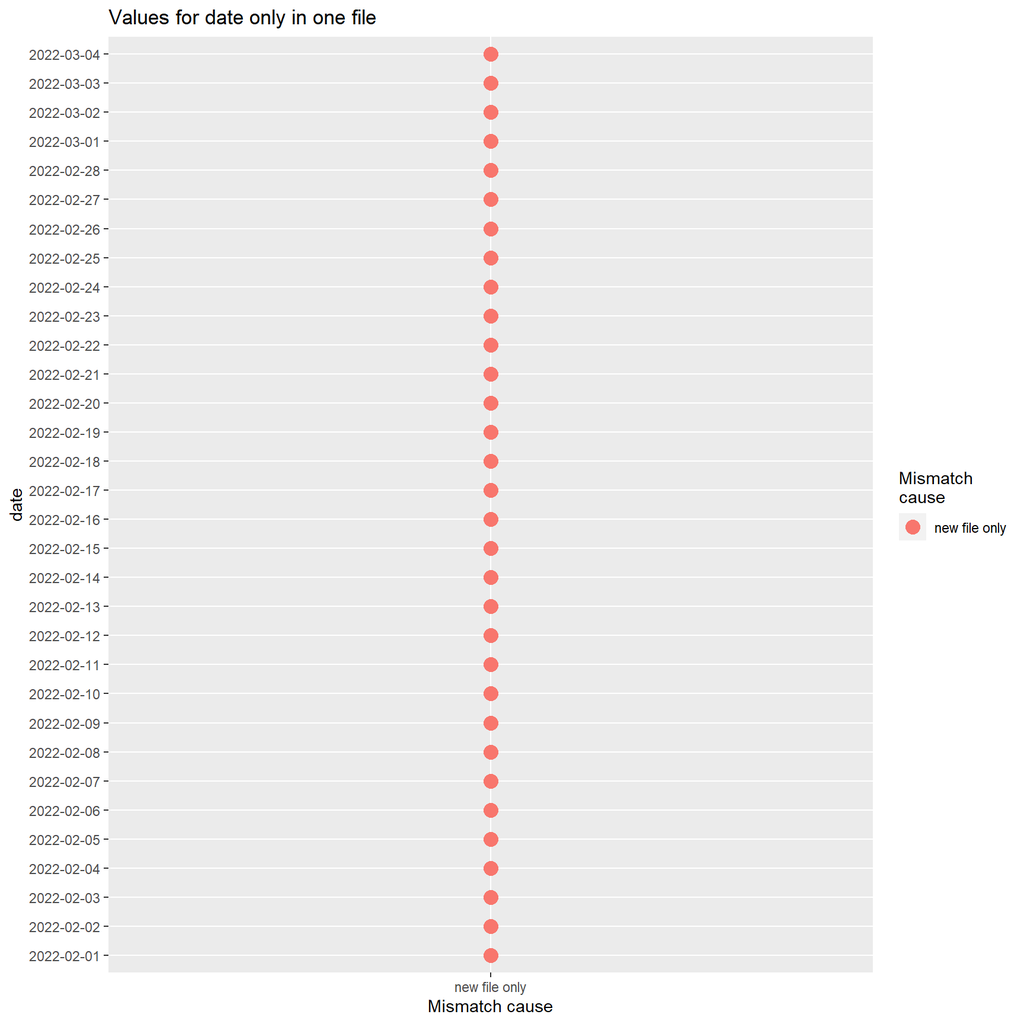

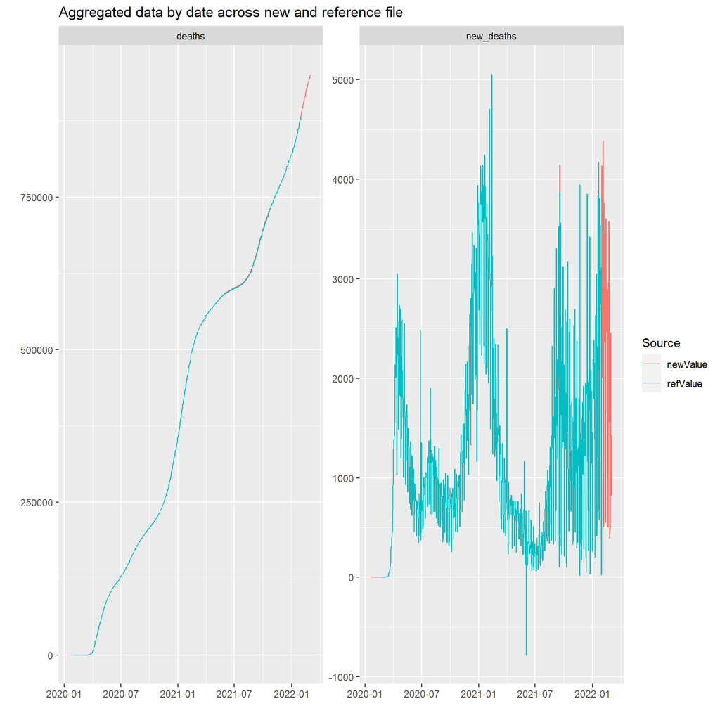

```
##
##
## ***Differences of at least 5 and at least 5%
##
## 44 records
## Detailed output available in log: ./RInputFiles/Coronavirus/USAF_NewData_20220308_chk_v005.log
```

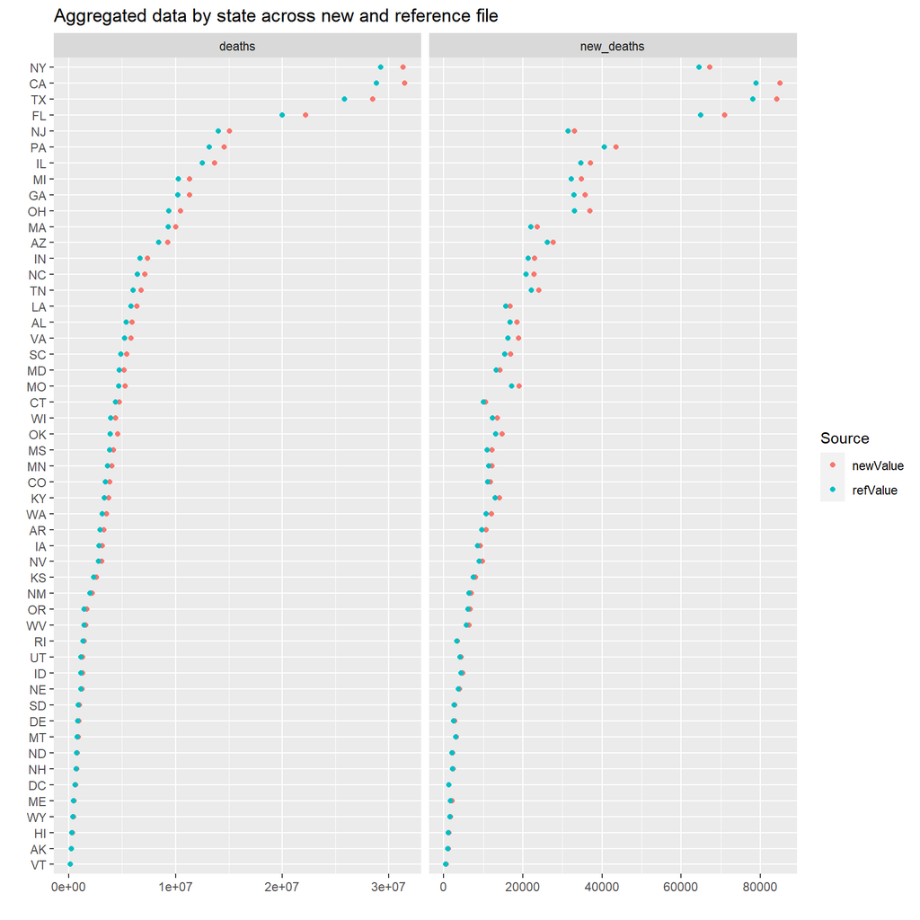

```
##
##
## ***Differences of at least 0 and at least 0.1%
##
## 253 records
## Detailed output available in log: ./RInputFiles/Coronavirus/USAF_NewData_20220308_chk_v005.log
##
##
## Column sums before and after applying filtering rules:
## # A tibble: 3 x 4
##   isType    cases new_cases            n
##   <chr>     <dbl>     <dbl>        <dbl>
## 1 before 1.92e+10   7.73e+7 2468189
## 2 after  1.90e+10   7.69e+7 2428766
## 3 pctchg 5.39e- 3   5.14e-3       0.0160
##
##
## Column sums before and after applying filtering rules:
## # A tibble: 3 x 4
##   isType  deaths  new_deaths            n
##   <chr>    <dbl>       <dbl>        <dbl>
## 1 before 3.27e+8 951208      2468189
## 2 after  3.20e+8 907057      2428766
## 3 pctchg 2.11e-2      0.0464       0.0160
```

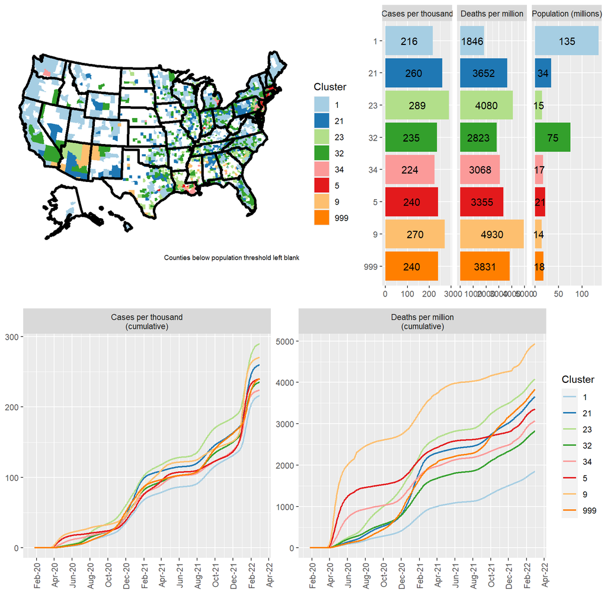

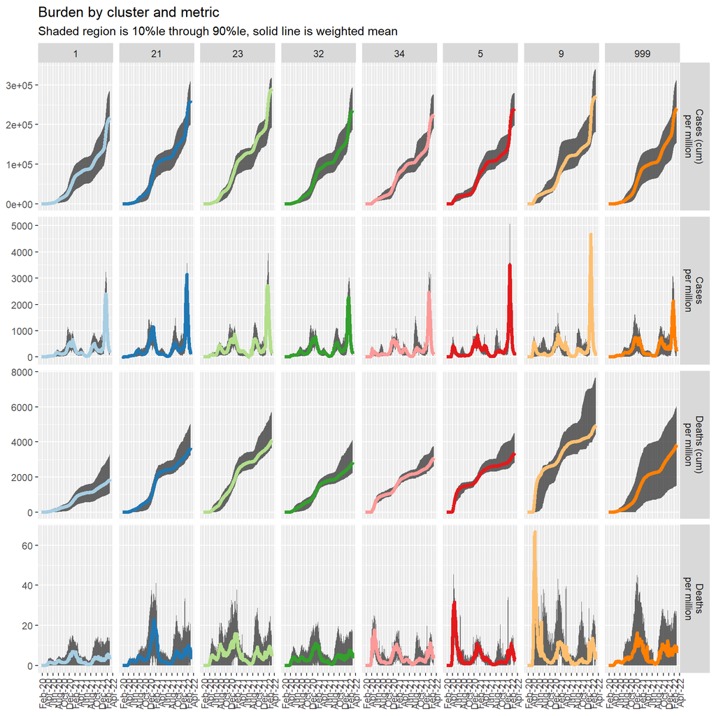

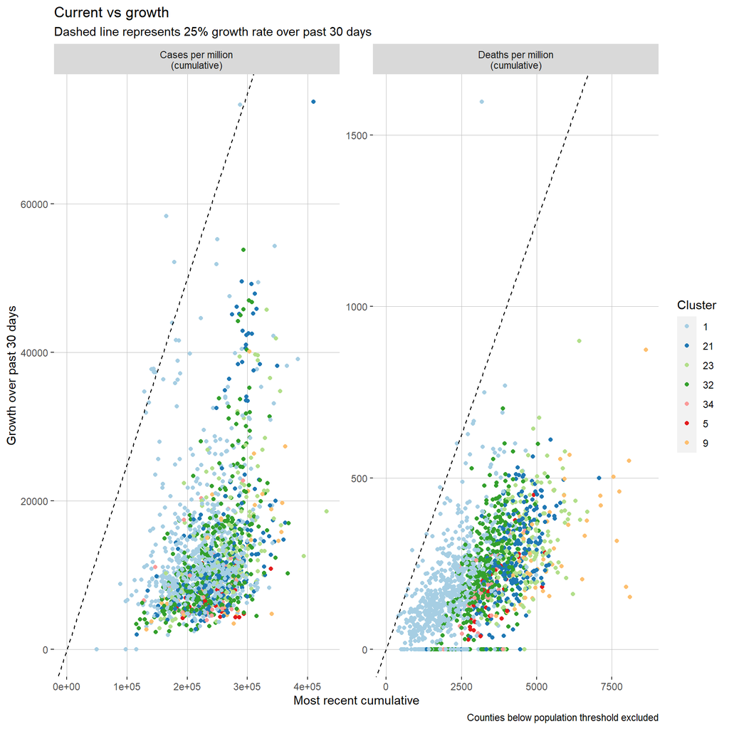

```r
urlMapper[["usafCase"]] <- "https://static.usafacts.org/public/data/covid-19/covid_confirmed_usafacts.csv"
urlMapper[["usafDeath"]] <- "https://static.usafacts.org/public/data/covid-19/covid_deaths_usafacts.csv"
urlMapper[["usafPop"]] <- "https://static.usafacts.org/public/data/covid-19/covid_county_population_usafacts.csv"

readList <- list("usafCase"="./RInputFiles/Coronavirus/covid_confirmed_usafacts_downloaded_20220308.csv",
                 "usafDeath"="./RInputFiles/Coronavirus/covid_deaths_usafacts_downloaded_20220308.csv"
                 )
compareList <- list("usafCase"=readFromRDS("cty_newdata_20220202")$dfRaw$usafCase,
                    "usafDeath"=readFromRDS("cty_newdata_20220202")$dfRaw$usafDeath
                    )

# Use existing clusters
cty_chkdata_20220308 <- readRunUSAFacts(maxDate="2022-03-06",
                                        downloadTo=lapply(readList,
                                                          FUN=function(x) if(file.exists(x)) NA else x
                                                          ),
                                        readFrom=readList,
                                        compareFile=compareList,
                                        writeLog="./RInputFiles/Coronavirus/USAF_NewData_20220308_chk_v005.log",
                                        ovrwriteLog=TRUE,
                                        useClusters=readFromRDS("cty_newdata_20210813")$useClusters,
                                        skipAssessmentPlots=FALSE,
                                        brewPalette="Paired"
                                        )
```

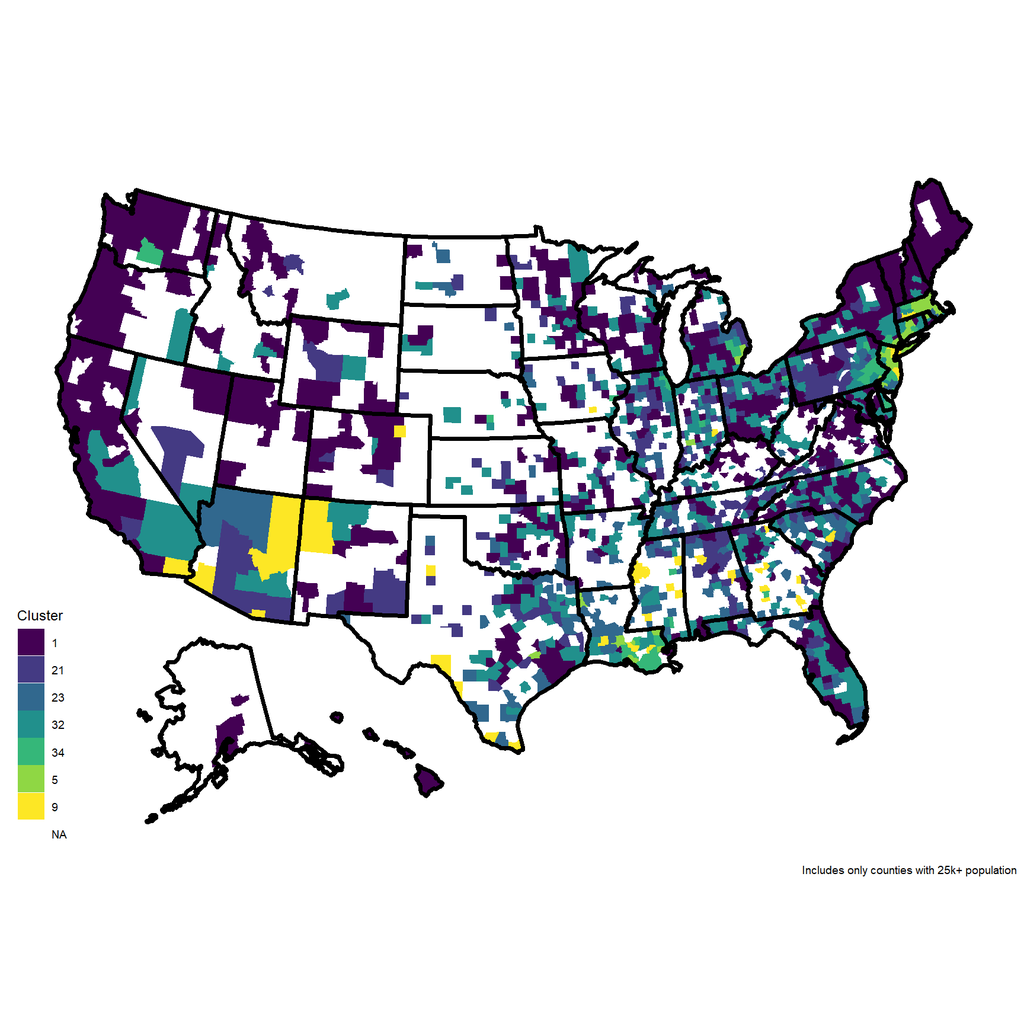

```r
# Plot all counties based on closest cluster
sparseCountyClusterMap(cty_chkdata_20220308$useClusters,
                       caption="Includes only counties with 25k+ population",
                       brewPalette="viridis"
                       )
```

```r
# Save the check file
saveToRDS(cty_chkdata_20220308, ovrWriteError=FALSE)
```

```
##
## File already exists: ./RInputFiles/Coronavirus/cty_chkdata_20220308.RDS
##
## Not replacing the existing file since ovrWrite=FALSE
```

```r
# Confirm that it is identical to the previous process
cty_newdata_20220308 <- readFromRDS("cty_newdata_20220308")
# Same names in the list
all.equal(names(cty_chkdata_20220308), names(cty_newdata_20220308))
```

```
## [1] TRUE
```

```r
# Identical items in the list
sapply(names(cty_chkdata_20220308),
       FUN=function(x) identical(cty_chkdata_20220308[[x]], cty_newdata_20220308[[x]])
       )
```

```
##   countyData        dfRaw    dfProcess  dfPerCapita  useClusters      maxDate
##         TRUE         TRUE         TRUE         TRUE         TRUE         TRUE
## plotDataList
##        FALSE
```

```r
# ggplot2 objects are never identical due to environment; confirm they are all.equal
all.equal(cty_chkdata_20220308$plotDataList, cty_newdata_20220308$plotDataList)
```

```
## [1] TRUE
```

The capability for obtaining and processing county-level vaccines data is included:

```r
# Read the relevant vaccines data
vaxPartialRaw_20220309 <- downloadCountyVaccines(loc="./RInputFiles/Coronavirus/county_vaccine_20220309.csv")
```

```
##
## Records from other than 50 states and DC:
## # A tibble: 9 x 2
##   state     n
##   <chr> <int>
## 1 AS      442
## 2 FM      447
## 3 GU      897
## 4 MH      434
## 5 MP      444
## 6 PR    35625
## 7 PW      441
## 8 UNK     308
## 9 VI     1794
```

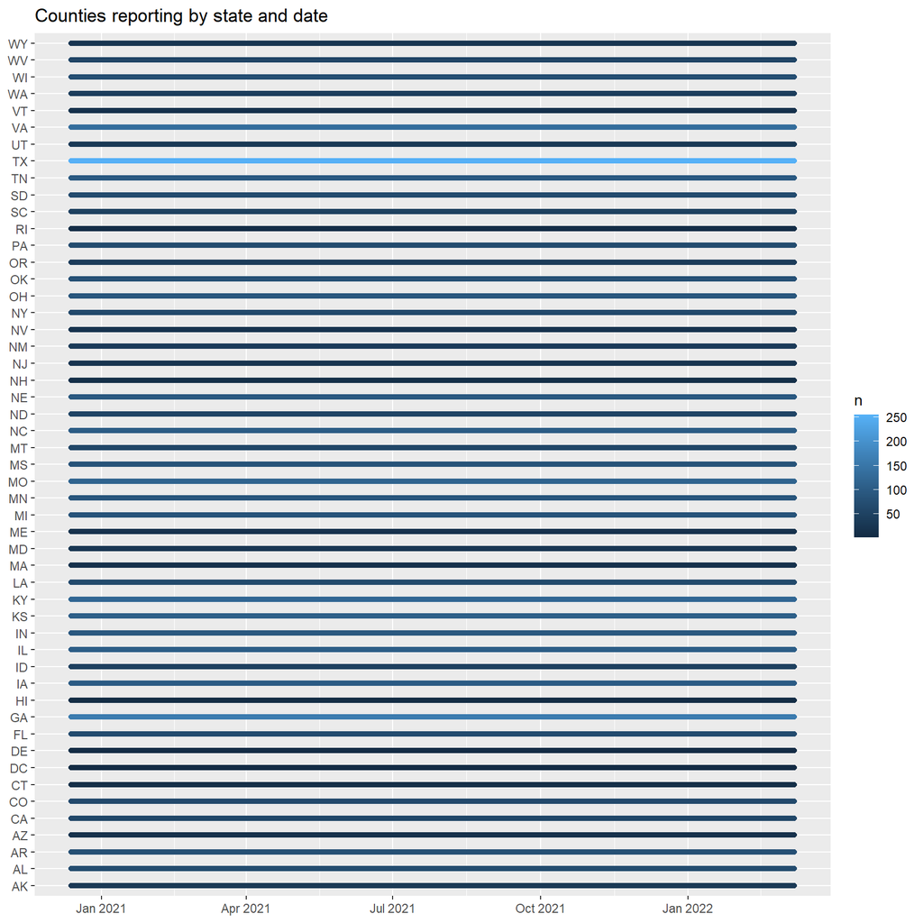

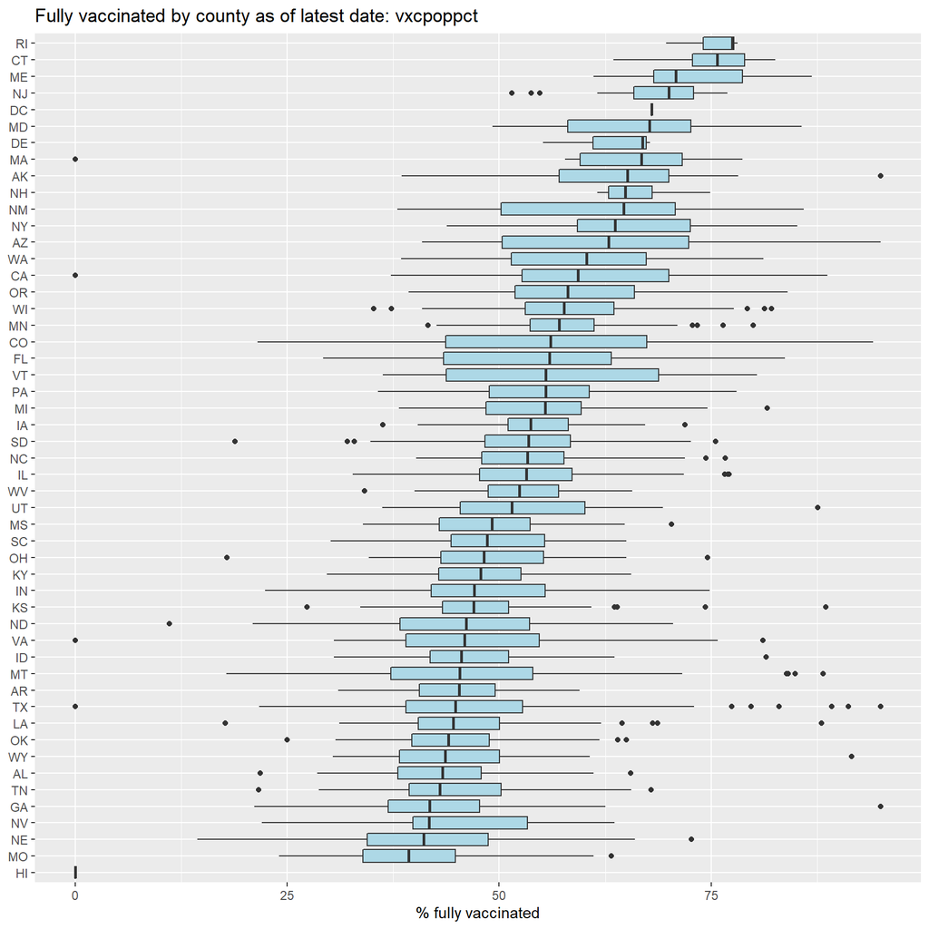

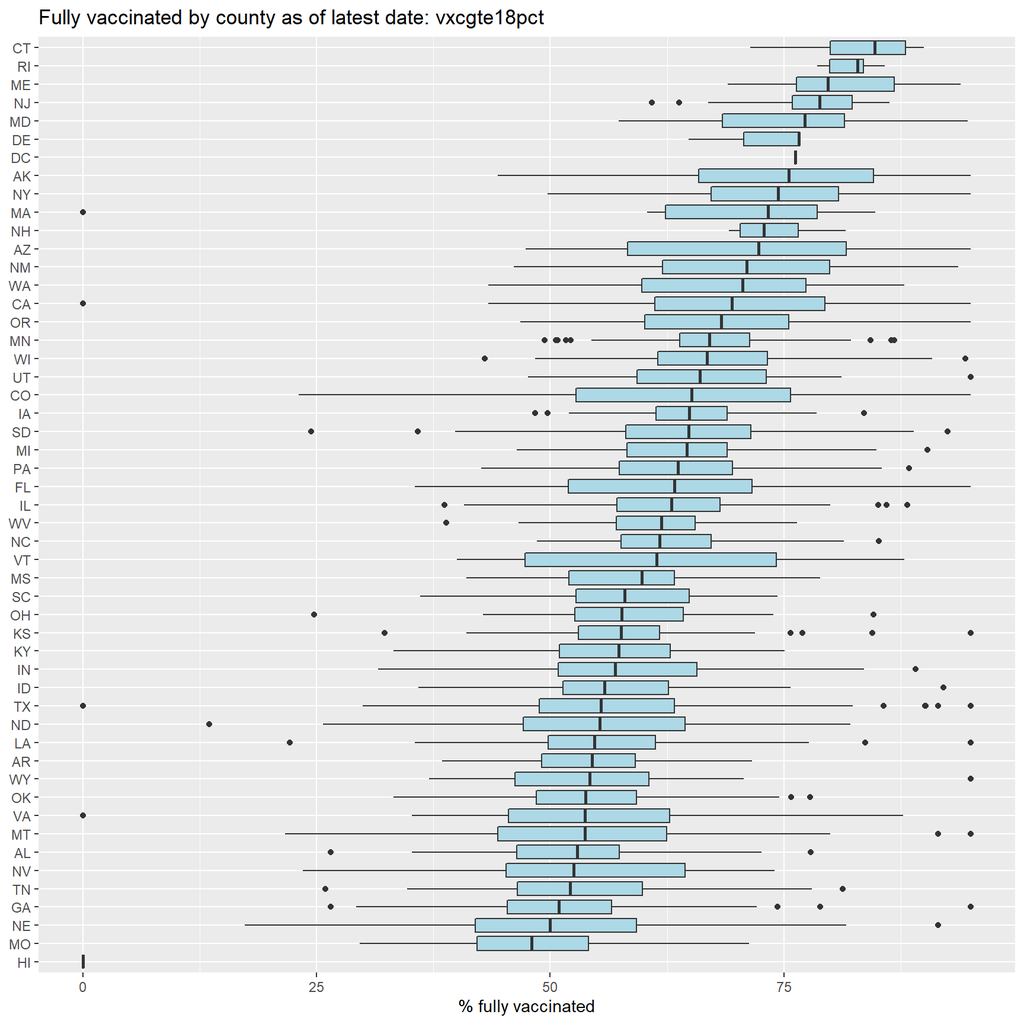

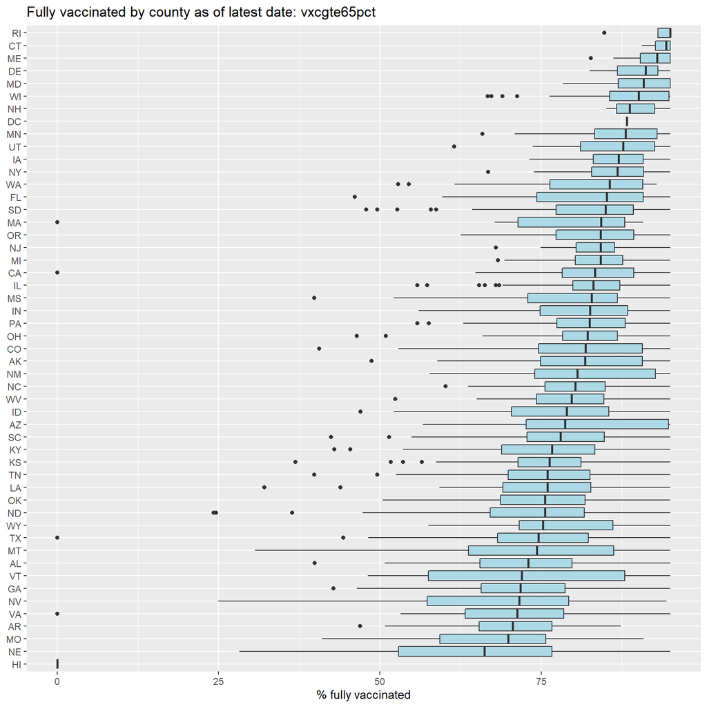

```r
vaxPartialRaw_20220309
```

```
## # A tibble: 1,480,110 x 10
##    date       FIPS  countyName    state vxcpoppct vxcgte18pct vxcgte65pct    pop
##    <date>     <chr> <chr>         <chr>     <dbl>       <dbl>       <dbl>  <dbl>
##  1 2022-03-08 06101 Sutter County CA         60.3        73          87.7  96971
##  2 2022-03-08 12009 Brevard Coun~ FL         64          72.9        88.4 601942
##  3 2022-03-08 19085 Harrison Cou~ IA         51.6        62.1        88.9  14049
##  4 2022-03-08 06069 San Benito C~ CA         66          75.6        83.3  62808
##  5 2022-03-08 19057 Des Moines C~ IA         51.1        61.9        83.4  38967
##  6 2022-03-08 05073 Lafayette Co~ AR         41.2        48.5        57.4   6624
##  7 2022-03-08 16021 Boundary Cou~ ID         34.8        42.8        63.6  12245
##  8 2022-03-08 20073 Greenwood Co~ KS         49          59.6        80.6   5982
##  9 2022-03-08 33005 Cheshire Cou~ NH         61.6        69.1        89.6  76085
## 10 2022-03-08 37159 Rowan County  NC         43.8        52.5        74.1 142088
## # ... with 1,480,100 more rows, and 2 more variables: popgte18 <dbl>,
## #   popgte65 <dbl>
```

```r
# Repair the data for 65+
vaxFix65_20220309 <- repairVaxPopulation(vaxPartialRaw_20220309, colsRepair=c("popgte65"))
```

```
##
## Count of NA records by column
##           state            FIPS popgte65_minpop popgte65_maxpop    popgte65_nnA
##               0               0               0               0               0
##               n
##               0
##
## Records where minimum and maximum population differ# A tibble: 0 x 5
## # ... with 5 variables: state <chr>, FIPS <chr>, age <chr>, minpop <dbl>,
## #   maxpop <dbl>
```

```r
vaxFix65_20220309
```

```
## # A tibble: 1,417,042 x 10
##    date       FIPS  countyName    state vxcpoppct vxcgte18pct vxcgte65pct    pop
##    <date>     <chr> <chr>         <chr>     <dbl>       <dbl>       <dbl>  <dbl>
##  1 2022-03-08 06101 Sutter County CA         60.3        73          87.7  96971
##  2 2022-03-08 12009 Brevard Coun~ FL         64          72.9        88.4 601942
##  3 2022-03-08 19085 Harrison Cou~ IA         51.6        62.1        88.9  14049
##  4 2022-03-08 06069 San Benito C~ CA         66          75.6        83.3  62808
##  5 2022-03-08 19057 Des Moines C~ IA         51.1        61.9        83.4  38967
##  6 2022-03-08 05073 Lafayette Co~ AR         41.2        48.5        57.4   6624
##  7 2022-03-08 16021 Boundary Cou~ ID         34.8        42.8        63.6  12245
##  8 2022-03-08 20073 Greenwood Co~ KS         49          59.6        80.6   5982
##  9 2022-03-08 33005 Cheshire Cou~ NH         61.6        69.1        89.6  76085
## 10 2022-03-08 37159 Rowan County  NC         43.8        52.5        74.1 142088
## # ... with 1,417,032 more rows, and 2 more variables: popgte18 <dbl>,
## #   popgte65 <dbl>
```

Correlations data can also be run:

```r
corrList20220309 <- corrVaxBurden(lstCD=cty_newdata_20220308,
                                  dfVax=vaxPartialRaw_20220309,
                                  minDateCD=c("2021-11-01", "2021-09-01"),
                                  maxDateCD="2022-02-28"
                                  )
```

```
##
## Will run with parameters:
## burdenVar: cpm dpm
## vaxVar: vxcpoppct vxcpoppct
## minDateCD: 2021-11-01 2021-09-01
## maxDateCD: 2022-02-28 2022-02-28
```

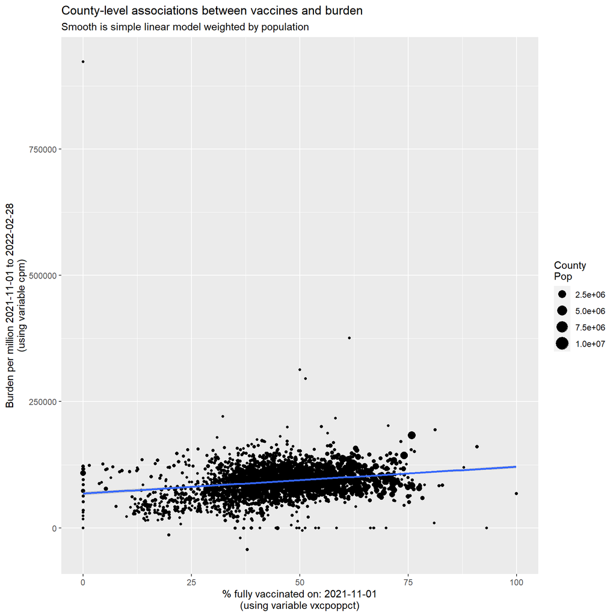

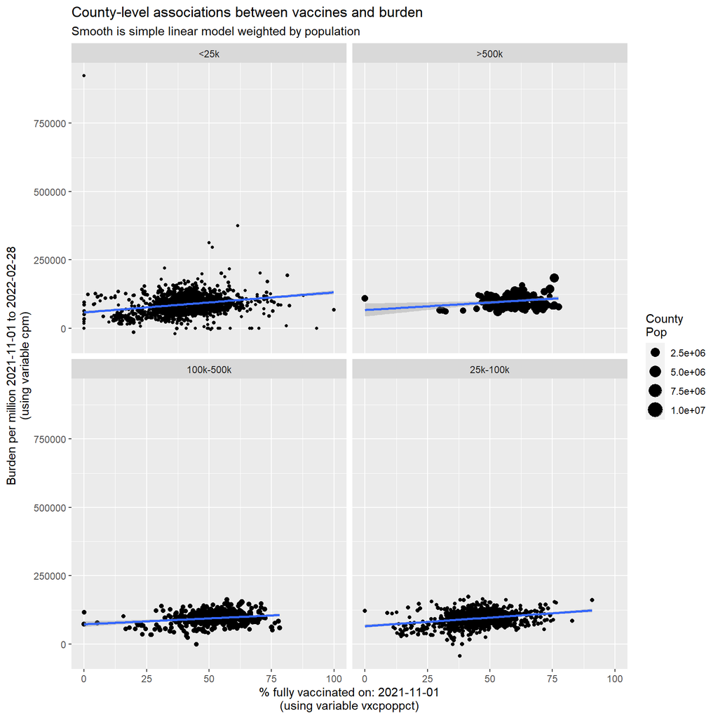

```
##
## Call:
## lm(formula = get(burdenVar) ~ vaxMetric, data = dfReg, weights = pop)
##
## Weighted Residuals:
##       Min        1Q    Median        3Q       Max
## -57553717  -2611410   -275030   2650218 123342871
##
## Coefficients:
##             Estimate Std. Error t value Pr(>|t|)
## (Intercept) 68194.65    1887.85   36.12   <2e-16 ***
## vaxMetric     530.27      33.93   15.63   <2e-16 ***
## ---
## Signif. codes:  0 '***' 0.001 '**' 0.01 '*' 0.05 '.' 0.1 ' ' 1
##
## Residual standard error: 7406000 on 3140 degrees of freedom
## Multiple R-squared:  0.07217,    Adjusted R-squared:  0.07187
## F-statistic: 244.2 on 1 and 3140 DF,  p-value: < 2.2e-16
##
##
## Call:
## lm(formula = get(burdenVar) ~ vaxMetric * type + 0 - vaxMetric,
##     data = dfReg, weights = pop)
##
## Weighted Residuals:
##       Min        1Q    Median        3Q       Max
## -57474876  -2595922   -291957   2584956 122543573
##
## Coefficients:
##                         Estimate Std. Error t value Pr(>|t|)
## type<25k                58253.65    6207.86   9.384  < 2e-16 ***
## type>500k               66890.28    3631.97  18.417  < 2e-16 ***
## type100k-500k           72662.44    3757.76  19.337  < 2e-16 ***
## type25k-100k            65791.22    4409.38  14.921  < 2e-16 ***
## vaxMetric:type<25k        731.64     145.96   5.013 5.67e-07 ***
## vaxMetric:type>500k       553.88      60.14   9.210  < 2e-16 ***
## vaxMetric:type100k-500k   429.71      69.68   6.167 7.84e-10 ***
## vaxMetric:type25k-100k    628.19      96.06   6.540 7.17e-11 ***
## ---
## Signif. codes:  0 '***' 0.001 '**' 0.01 '*' 0.05 '.' 0.1 ' ' 1
##
## Residual standard error: 7400000 on 3134 degrees of freedom
## Multiple R-squared:  0.9476, Adjusted R-squared:  0.9474
## F-statistic:  7081 on 8 and 3134 DF,  p-value: < 2.2e-16
```

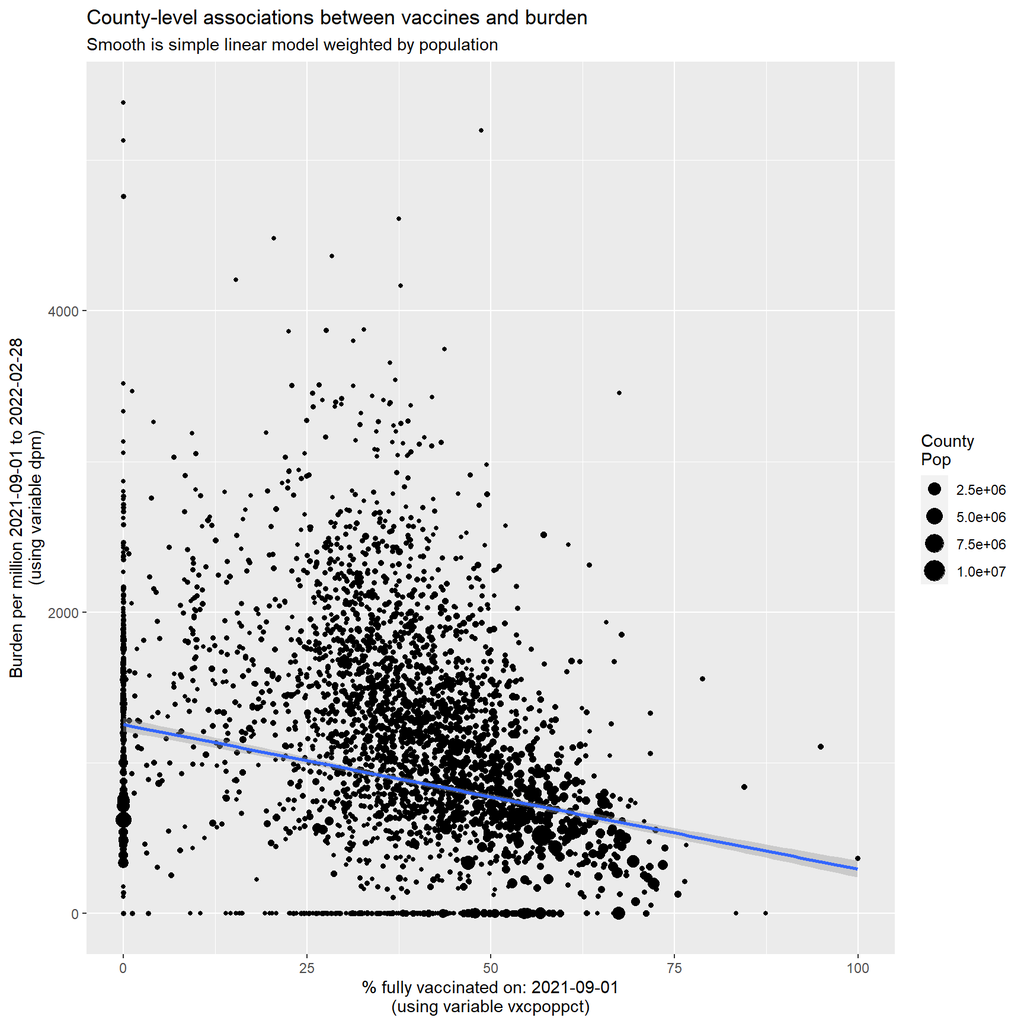

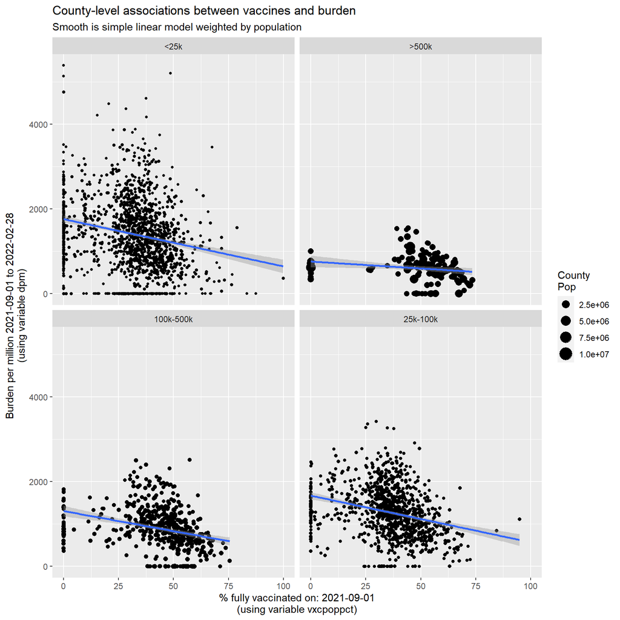

```
##
## Call:
## lm(formula = get(burdenVar) ~ vaxMetric, data = dfReg, weights = pop)
##
## Weighted Residuals:
##      Min       1Q   Median       3Q      Max
## -1371927   -23067    44651   121402   729890
##
## Coefficients:
##              Estimate Std. Error t value Pr(>|t|)
## (Intercept) 1254.2057    22.8836   54.81   <2e-16 ***
## vaxMetric     -9.5890     0.4779  -20.07   <2e-16 ***
## ---
## Signif. codes:  0 '***' 0.001 '**' 0.01 '*' 0.05 '.' 0.1 ' ' 1
##
## Residual standard error: 160100 on 3140 degrees of freedom
## Multiple R-squared:  0.1136, Adjusted R-squared:  0.1134
## F-statistic: 402.6 on 1 and 3140 DF,  p-value: < 2.2e-16
##
##
## Call:
## lm(formula = get(burdenVar) ~ vaxMetric * type + 0 - vaxMetric,
##     data = dfReg, weights = pop)
##
## Weighted Residuals:
##     Min      1Q  Median      3Q     Max
## -885434  -65276   -4779   67115 1060610
##
## Coefficients:
##                          Estimate Std. Error t value Pr(>|t|)
## type<25k                1760.1655    74.0739  23.762  < 2e-16 ***
## type>500k                758.0391    29.0606  26.085  < 2e-16 ***
## type100k-500k           1304.8595    41.8238  31.199  < 2e-16 ***
## type25k-100k            1668.2572    50.2491  33.200  < 2e-16 ***
## vaxMetric:type<25k       -11.1910     2.0925  -5.348 9.52e-08 ***
## vaxMetric:type>500k       -3.2769     0.5600  -5.851 5.38e-09 ***
## vaxMetric:type100k-500k   -9.4838     0.8902 -10.653  < 2e-16 ***
## vaxMetric:type25k-100k   -11.0196     1.2902  -8.541  < 2e-16 ***
## ---
## Signif. codes:  0 '***' 0.001 '**' 0.01 '*' 0.05 '.' 0.1 ' ' 1
##
## Residual standard error: 140000 on 3134 degrees of freedom
## Multiple R-squared:  0.8063, Adjusted R-squared:  0.8058
## F-statistic:  1631 on 8 and 3134 DF,  p-value: < 2.2e-16
```

```r
corrList20220309
```

```
## [[1]]
## # A tibble: 3,142 x 10
##    fips  countyName     pop state vxcpoppct vxcgte18pct vxcgte65pct    cpm   dpm
##    <chr> <chr>        <dbl> <chr>     <dbl>       <dbl>       <dbl>  <dbl> <dbl>
##  1 42129 Westmorela~ 348899 PA         54.2        63.2        81.2 96676. 1238.
##  2 39109 Miami Coun~ 106987 OH         42.8        53          77.6 91619. 1318.
##  3 16045 Gem County   18112 ID         34.5        44.7        71   44611.  939.
##  4 05071 Johnson Co~  26578 AR         44.4        54.8        67.7 74761.  452.
##  5 48411 San Saba C~   6055 TX         32.7        40          54.4 38811.  991.
##  6 51710 Norfolk ci~ 242742 VA         48.2        56.7        79.4 69044.  470.
##  7 27007 Beltrami C~  47188 MN         52.5        64.7        91.4 94982.  805.
##  8 05067 Jackson Co~  16719 AR         34.4        41.2        66.9 98870.  658.
##  9 51735 Poquoson c~  12271 VA         43.5        52.8        69.7 79945.  652.
## 10 47047 Fayette Co~  41133 TN         49.2        57.9        76.3 97610. 1386.
## # ... with 3,132 more rows, and 1 more variable: type <chr>
##
## [[2]]
## # A tibble: 3,142 x 10
##    fips  countyName     pop state vxcpoppct vxcgte18pct vxcgte65pct    cpm   dpm
##    <chr> <chr>        <dbl> <chr>     <dbl>       <dbl>       <dbl>  <dbl> <dbl>
##  1 51710 Norfolk ci~ 242742 VA         39.4        46.7        68.7 8.43e4  704.
##  2 01127 Walker Cou~  63521 AL         32.7        41          68.1 1.46e5 1810.
##  3 28153 Wayne Coun~  20183 MS         27.1        34.7        58.2 1.06e5 1288.
##  4 26045 Eaton Coun~ 110268 MI         47.4        56.5        77.4 1.41e5 1533.
##  5 48313 Madison Co~  14284 TX          0           0           0   1.00e5 1050.
##  6 39095 Lucas Coun~ 428348 OH         39.2        48.2        67.2 1.22e5 1158.
##  7 29153 Ozark Coun~   9174 MO         24.7        30          41   7.60e4 3052.
##  8 29071 Franklin C~ 103967 MO         44.5        55          81.4 9.62e4 1212.
##  9 21149 McLean Cou~   9207 KY         40.9        51.6        76.7 1.56e5 1629.
## 10 13233 Polk County  42613 GA          9.4        11.7         9.8 9.84e4 1877.
## # ... with 3,132 more rows, and 1 more variable: type <chr>
```

Comparisons can be run between summed county and state data:

```r
statePerCapita <- readFromRDS("cdc_daily_220304")$dfPerCapita

tempStateCompareList <- compareStateSummedCounty(dfState=statePerCapita,
                                                 dfCounty=cty_newdata_20220308$dfPerCapita,
                                                 aggData=TRUE,
                                                 dateThru="2022-02-28",
                                                 returnData=TRUE
                                                 )
```

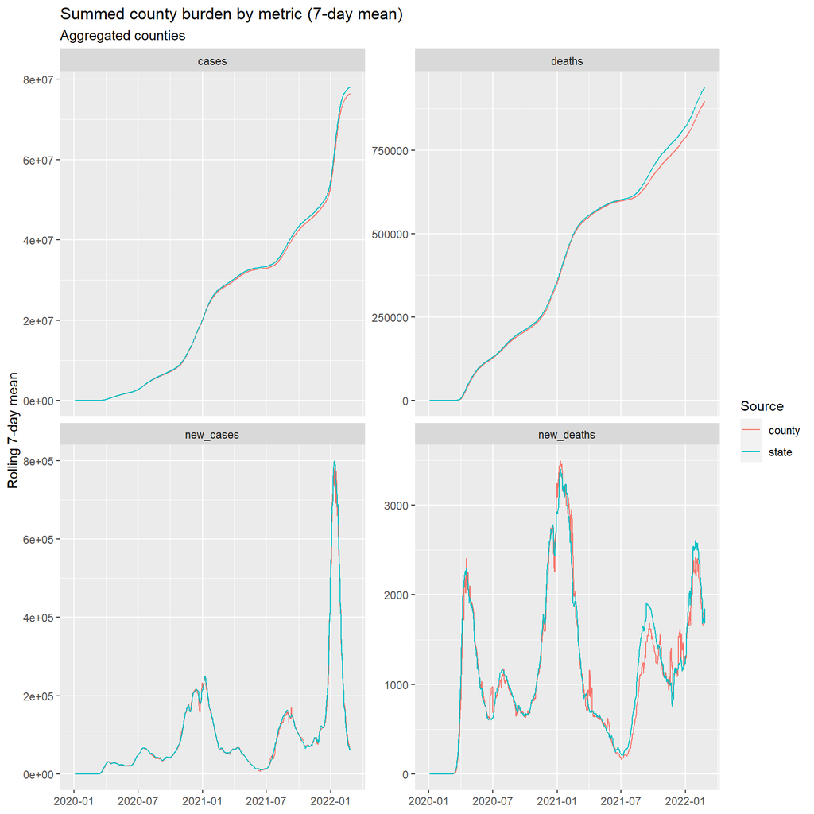

```r
tempStateCompareList
```

```
## $dfState
## # A tibble: 3,160 x 6
##    date       name       src   value value7 state
##    <date>     <chr>      <chr> <dbl>  <dbl> <chr>
##  1 2020-01-01 cases      state     0     NA Aggregated
##  2 2020-01-01 deaths     state     0     NA Aggregated
##  3 2020-01-01 new_cases  state     0     NA Aggregated
##  4 2020-01-01 new_deaths state     0     NA Aggregated
##  5 2020-01-02 cases      state     0     NA Aggregated
##  6 2020-01-02 deaths     state     0     NA Aggregated
##  7 2020-01-02 new_cases  state     0     NA Aggregated
##  8 2020-01-02 new_deaths state     0     NA Aggregated
##  9 2020-01-03 cases      state     0     NA Aggregated
## 10 2020-01-03 deaths     state     0     NA Aggregated
## # ... with 3,150 more rows
##
## $dfCounty
## # A tibble: 3,052 x 6
##    date       name       src    value  value7 state
##    <date>     <chr>      <chr>  <dbl>   <dbl> <chr>
##  1 2020-01-25 cases      county   751 750.    Aggregated
##  2 2020-01-25 deaths     county     1   1     Aggregated
##  3 2020-01-25 new_cases  county    10 111.    Aggregated
##  4 2020-01-25 new_deaths county     0   0.143 Aggregated
##  5 2020-01-26 cases      county   759 758.    Aggregated
##  6 2020-01-26 deaths     county     1   1     Aggregated
##  7 2020-01-26 new_cases  county     8   8     Aggregated
##  8 2020-01-26 new_deaths county     0   0     Aggregated
##  9 2020-01-27 cases      county   769 766.    Aggregated
## 10 2020-01-27 deaths     county     1   1     Aggregated
## # ... with 3,042 more rows
```

The scoring metric is converted to functional form:

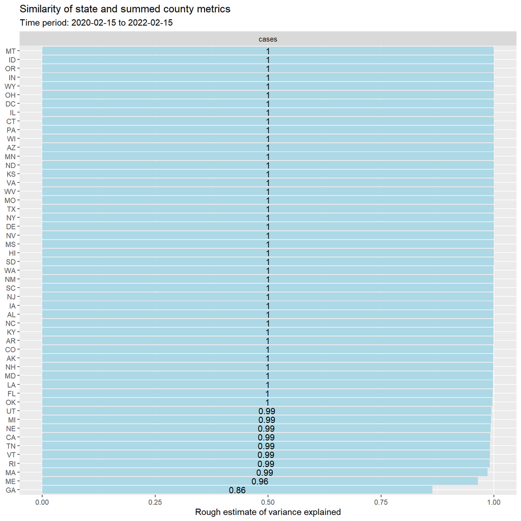

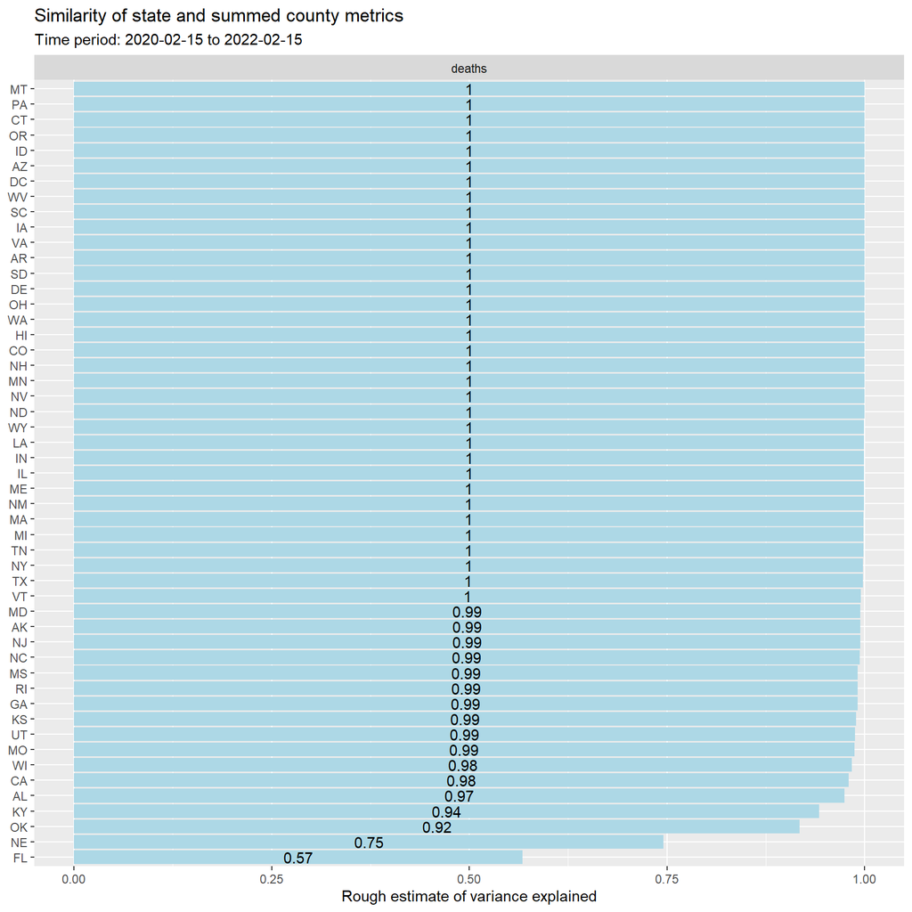

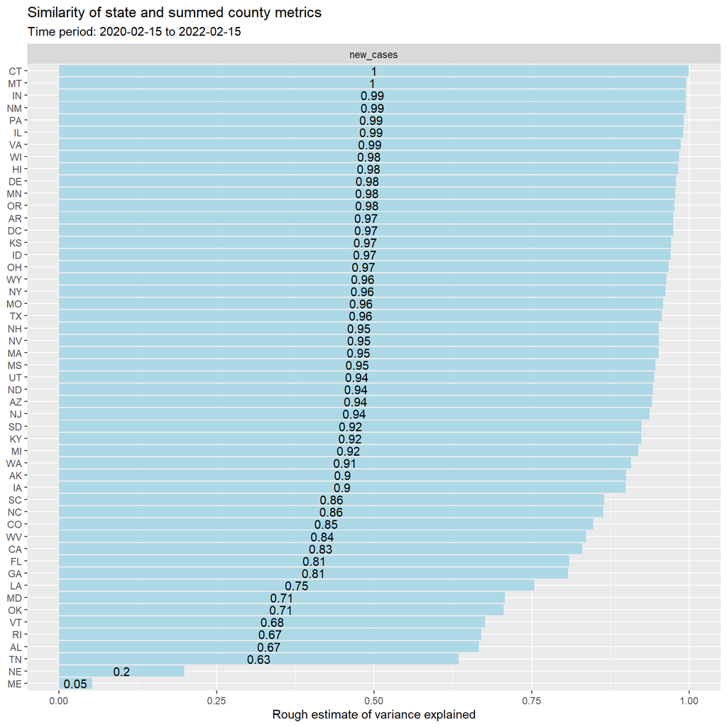

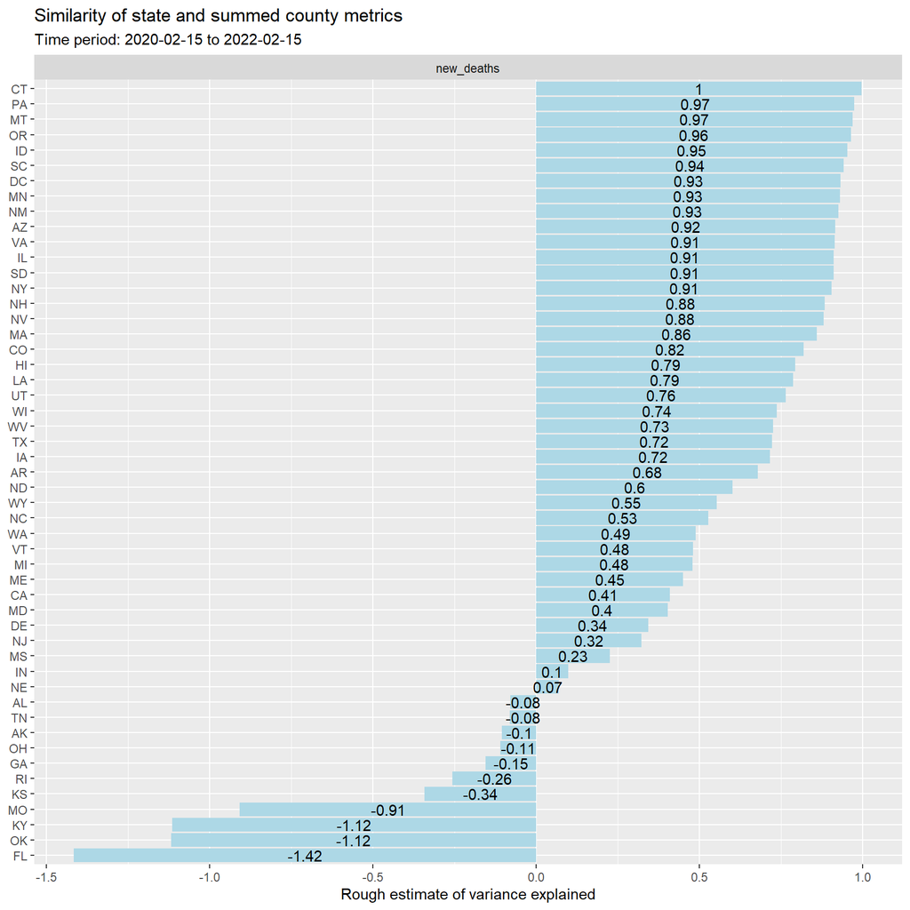

```r
# Data for score similarity process
tempStateCompareList_v2 <- compareStateSummedCounty(dfState=statePerCapita,
                                                    dfCounty=cty_newdata_20220308$dfPerCapita,
                                                    inclStates=c(state.abb, "DC"),
                                                    dateThru="2022-02-28",
                                                    makePlot=FALSE,
                                                    returnData=TRUE
                                                    )
scoreSimilarity(tempStateCompareList_v2, minDate="2020-02-15", maxDate="2022-02-15", makeFacet=FALSE)
```